# Project 1: Wrangling, Exploration, Visualization

SDS322E

## Data Wrangling, Exploration, Visualization

### Jessica de Jong JLD4864

#### Introduction

For this project, I chose two data-sets to combine and explore: One data-set shows data on suicide rates by country, among other variables like age, population number, sex, year, and generation. The other data-set shows income of countries by year, also including the variables of region and income group. These two datasets share the ID variables of country and year. I chose these two because I thought it would be interesting to see if there was correlation between income and suicide rates by country - for example, could the United States have lower suicide rates than a lower income country, like Guinea? I would predict that in countries that suffer from poverty, suicide rates would be higher.

```r
# reading in my data-sets
library(tidyverse)
data1 <- read_csv("suiciderates.csv")
data2 <- read_csv("incomebycountry.csv")
```

#### Tidying: Reshaping

```r
# my tidying code:
untidydata1 <- data1 %>% pivot_wider(names_from = generation,
    values_from = age)

tidydata1 <- untidydata1 %>% pivot_longer(cols = c("Silent",
    "G.I. Generation", "Boomers", "Generation X", "Millenials",
    "Generation Z"), names_to = "generation", values_to = "age",
    values_drop_na = TRUE)

tidydata1 <- tidydata1 %>% mutate(year = as.numeric(year))

tidydata2 <- data2 %>% pivot_longer(cols = c(starts_with("19"),
    starts_with("20")), names_to = "year", values_to = "Average_Income",
    values_drop_na = TRUE)

tidydata2 <- tidydata2 %>% mutate(year = as.numeric(year))
```

My first data-set of suicide rates was already tidy. I untidied the data-set by using the pivot_wider function and removing the generation names, and then tidied the data-set back by using the pivot_longer function and re-adding the generation names. My second data-set was not tidy in regard to the years being displayed, so I used the pivot_longer function to grab any values that began with 19 and 20 (e.g. the years 1987 - 2020). I also included the mutate function here on both tidy data-sets in order for the resulting combined data-sets to be acknowledged as numeric data later on in the wrangling portion of this project.

#### Joining/Merging

```r
# my joining code:
joinedData <- full_join(tidydata1, tidydata2)

joinData <- joinedData %>% mutate(population = as.numeric(population),
    Average_Income = as.numeric(Average_Income))

count(tidydata1)
```

```
## # A tibble: 1 x 1
##       n
##   <int>
## 1 27816
```

```r
count(tidydata2)
```

```
## # A tibble: 1 x 1
##       n
##   <int>
## 1  7378
```

```r
count(joinData)
```

```
## # A tibble: 1 x 1
##       n
##   <int>
## 1 33122
```

#### Wrangling

```r
# my wrangling code create a new variable with mutate
# function
mutateJoinedData <- joinData %>% mutate(EstimatedGDPforGeneration = as.numeric(population) *
    as.numeric(Average_Income), EstimatedGDPforGeneration = as.numeric(EstimatedGDPforGeneration))

# use stringr function
mutateJoinedData %>% filter(str_detect("Income Group", "Low.*")) %>%
    arrange(population)
```

```
## # A tibble: 0 x 13
## # … with 13 variables: Country <chr>, year <dbl>, sex <chr>, suicides_no <dbl>,
## #   population <dbl>, suicides_per_100k_pop <dbl>, generation <chr>,
## #   age <list>, `Income group` <chr>, Region <chr>, `Lending category` <chr>,
## #   Average_Income <dbl>, EstimatedGDPforGeneration <dbl>
```

```r
# summary statistics
mutateJoinedData %>% arrange(desc("suicides_no")) %>% glimpse()
```

```
## Rows: 33,122
## Columns: 13
## $ Country                   <chr> "Albania", "Albania", "Albania", "Albania",…
## $ year                      <dbl> 1987, 1987, 1987, 1987, 1987, 1987, 1987, 1…
## $ sex                       <chr> "male", "male", "female", "male", "male", "…
## $ suicides_no               <dbl> 21, 16, 14, 1, 9, 1, 6, 4, 1, 0, 0, 0, 2, 1…
## $ population                <dbl> 312900, 308000, 289700, 21800, 274300, 3560…
## $ suicides_per_100k_pop     <dbl> 6.71, 5.19, 4.83, 4.59, 3.28, 2.81, 2.15, 1…
## $ generation                <chr> "Generation X", "Silent", "Generation X", "…
## $ age                       <list> ["15-24 years", "35-54 years", "15-24 year…
## $ `Income group`            <chr> "Upper middle income", "Upper middle income…
## $ Region                    <chr> "Europe & Central Asia", "Europe & Central …
## $ `Lending category`        <chr> "IBRD", "IBRD", "IBRD", "IBRD", "IBRD", "IB…
## $ Average_Income            <dbl> 730, 730, 730, 730, 730, 730, 730, 730, 730…
## $ EstimatedGDPforGeneration <dbl> 228417000, 224840000, 211481000, 15914000, …
```

```r
mutateJoinedData %>% select("Country", "generation", "suicides_no",
    "suicides_per_100k_pop", "Average_Income")
```

```
## # A tibble: 33,122 x 5
##    Country generation      suicides_no suicides_per_100k_pop Average_Income
##    <chr>   <chr>                 <dbl>                 <dbl>          <dbl>
##  1 Albania Generation X             21                  6.71            730
##  2 Albania Silent                   16                  5.19            730
##  3 Albania Generation X             14                  4.83            730
##  4 Albania G.I. Generation           1                  4.59            730
##  5 Albania Boomers                   9                  3.28            730
##  6 Albania G.I. Generation           1                  2.81            730
##  7 Albania Silent                    6                  2.15            730
##  8 Albania Boomers                   4                  1.56            730
##  9 Albania G.I. Generation           1                  0.73            730
## 10 Albania Generation X              0                  0               730
## # … with 33,112 more rows
```

```r
mutateJoinedData %>% filter(generation == "Silent") %>% filter(year ==
    2015) %>% filter(is.na(Average_Income) == FALSE) %>% group_by(Country,
    "Income Group") %>% summarize(Average_Income = mean(Average_Income))
```

```
## # A tibble: 59 x 3
## # Groups:   Country [59]
##    Country             `"Income Group"` Average_Income
##    <chr>               <chr>                     <dbl>
##  1 Antigua and Barbuda Income Group              12850
##  2 Argentina           Income Group              12570
##  3 Armenia             Income Group               4010
##  4 Australia           Income Group              60500
##  5 Austria             Income Group              47480
##  6 Belgium             Income Group              45570
##  7 Belize              Income Group               4400
##  8 Brazil              Income Group              10190
##  9 Chile               Income Group              14130
## 10 Colombia            Income Group               7330
## # … with 49 more rows
```

```r
mutateJoinedData %>% filter(generation == "Silent") %>% filter(year ==
    2015) %>% filter(is.na(Average_Income) == FALSE) %>% group_by(Country,
    "Income group") %>% summarize(MedianSuicide = median(suicides_no))
```

```
## # A tibble: 59 x 3
## # Groups:   Country [59]
##    Country             `"Income group"` MedianSuicide
##    <chr>               <chr>                    <dbl>
##  1 Antigua and Barbuda Income group               0
##  2 Argentina           Income group             136
##  3 Armenia             Income group               8.5
##  4 Australia           Income group             116.
##  5 Austria             Income group             142
##  6 Belgium             Income group             132
##  7 Belize              Income group               0.5
##  8 Brazil              Income group             280.
##  9 Chile               Income group              69
## 10 Colombia            Income group              46
## # … with 49 more rows
```

```r
mutateJoinedData %>% filter(generation == "Silent") %>% filter(year ==
    2015) %>% filter(is.na(Average_Income) == FALSE) %>% summarize(NDistinctSuicidesPer100kPop = n_distinct(suicides_per_100k_pop))
```

```
## # A tibble: 1 x 1
##   NDistinctSuicidesPer100kPop
##                         <int>
## 1                         100
```

```r
mutateJoinedData %>% filter(generation == "Silent") %>% filter(year ==
    2015) %>% filter(is.na(Average_Income) == FALSE) %>% group_by(Country,
    "Income group") %>% summarize(minEstimatedGDPforGeneration = min(EstimatedGDPforGeneration))
```

```
## # A tibble: 59 x 3
## # Groups:   Country [59]
##    Country             `"Income group"` minEstimatedGDPforGeneration
##    <chr>               <chr>                                   <dbl>
##  1 Antigua and Barbuda Income group                         13967950
##  2 Argentina           Income group                       8958525870
##  3 Armenia             Income group                        246033550
##  4 Australia           Income group                      40764113500
##  5 Austria             Income group                      13784820920
##  6 Belgium             Income group                      17898756750
##  7 Belize              Income group                          9961600
##  8 Brazil              Income group                      24950826400
##  9 Chile               Income group                       3989012040
## 10 Colombia            Income group                       3681331240
## # … with 49 more rows
```

```r
mutateJoinedData %>% filter(generation == "Silent") %>% filter(year ==
    2015) %>% filter(is.na(Average_Income) == FALSE) %>% group_by(Country,
    "Income group") %>% summarize(maxEstimatedGDPforGeneration = max(EstimatedGDPforGeneration))
```

```
## # A tibble: 59 x 3
## # Groups:   Country [59]
##    Country             `"Income group"` maxEstimatedGDPforGeneration
##    <chr>               <chr>                                   <dbl>
##  1 Antigua and Barbuda Income group                         22153400
##  2 Argentina           Income group                      16906398600
##  3 Armenia             Income group                        404023540
##  4 Australia           Income group                      53502993500
##  5 Austria             Income group                      21920376480
##  6 Belgium             Income group                      28080279570
##  7 Belize              Income group                         10700800
##  8 Brazil              Income group                      38743256340
##  9 Chile               Income group                       6649832340
## 10 Colombia            Income group                       5241272520
## # … with 49 more rows
```

```r
mutateJoinedData %>% filter(generation == "Silent") %>% filter(year ==
    2015) %>% filter(is.na(Average_Income) == FALSE) %>% group_by(Country,
    "Income group") %>% summarize(n())
```

```
## # A tibble: 59 x 3
## # Groups:   Country [59]
##    Country             `"Income group"` `n()`
##    <chr>               <chr>            <int>
##  1 Antigua and Barbuda Income group         2
##  2 Argentina           Income group         2
##  3 Armenia             Income group         2
##  4 Australia           Income group         2
##  5 Austria             Income group         2
##  6 Belgium             Income group         2
##  7 Belize              Income group         2
##  8 Brazil              Income group         2
##  9 Chile               Income group         2
## 10 Colombia            Income group         2
## # … with 49 more rows
```

```r
mutateJoinedData %>% filter(generation == "Silent") %>% filter(year ==
    2015) %>% filter(is.na(Average_Income) == FALSE) %>% group_by(Country,
    "Income group") %>% summarize(StandardEstimatedGDPforGeneration = sd(EstimatedGDPforGeneration))
```

```
## # A tibble: 59 x 3
## # Groups:   Country [59]
##    Country             `"Income group"` StandardEstimatedGDPforGeneration
##    <chr>               <chr>                                        <dbl>
##  1 Antigua and Barbuda Income group                              5787987.
##  2 Argentina           Income group                           5619994703.
##  3 Armenia             Income group                            111715793.
##  4 Australia           Income group                           9007748433.
##  5 Austria             Income group                           5752706505.
##  6 Belgium             Income group                           7199423829.
##  7 Belize              Income group                               522693.
##  8 Brazil              Income group                           9752720740.
##  9 Chile               Income group                           1881484078.
## 10 Colombia            Income group                           1103045057.
## # … with 49 more rows
```

```r
myownfunction <- function(x) (x - mean(x))
mutateJoinedData %>% filter(generation == "Silent") %>% filter(year ==
    2015) %>% filter(is.na(Average_Income == FALSE)) %>% group_by(Country,
    "Income group") %>% summarize(MeanCenteredPop = myownfunction(population))
```

```
## # A tibble: 6 x 3
## # Groups:   Country, "Income group" [3]
##   Country                      `"Income group"` MeanCenteredPop
##   <chr>                        <chr>                      <dbl>
## 1 Kyrgyzstan                   Income group             -15522.
## 2 Kyrgyzstan                   Income group              15522.
## 3 Republic of Korea            Income group            -388567
## 4 Republic of Korea            Income group             388567
## 5 Saint Vincent and Grenadines Income group                276.
## 6 Saint Vincent and Grenadines Income group               -276.
```

```r
statstable <- mutateJoinedData %>% group_by("Income group", generation) %>%
    summarize(n())

# install.packages('gt')
library("gt")

statstable %>% pivot_wider(names_from = generation, values_from = "n()") %>%
    gt() %>% tab_header(title = "Income per Generation")
```

Income per Generation

| Boomers | G.I. Generation | Generation X | Generation Z | Millenials | Silent | NA |
| --- | --- | --- | --- | --- | --- | --- |
| Income group |  |  |  |  |  |  |
| 4987 | 2744 | 6408 | 1470 | 5843 | 6364 | 5306 |

#### Visualizing

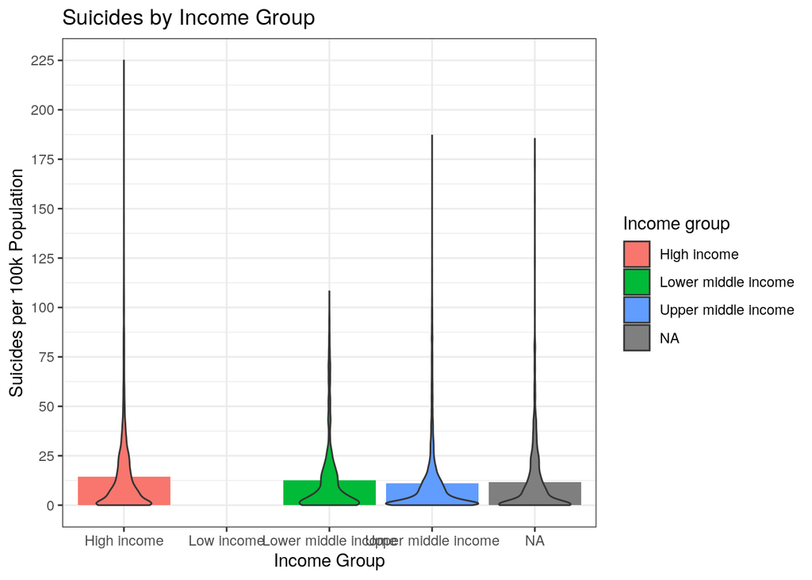

```r
# my plot 1: Suicides by Income Group

ggplot(mutateJoinedData, aes(`Income group`, suicides_per_100k_pop,
    fill = `Income group`)) + geom_bar(stat = "summary") + theme(text = element_text(size = 2)) +
    theme_bw() + scale_y_continuous(n.breaks = 10) + xlab("Income Group") +
    ylab("Suicides per 100k Population") + ggtitle("Suicides by Income Group") +
    geom_violin()
```

Countries with the highest income group have higher rates of suicide - this goes against my initial prediction noted in my introduction. I assumed that because of stress among people in poverty-stricken areas, suicide rates in lower income countries would be higher.

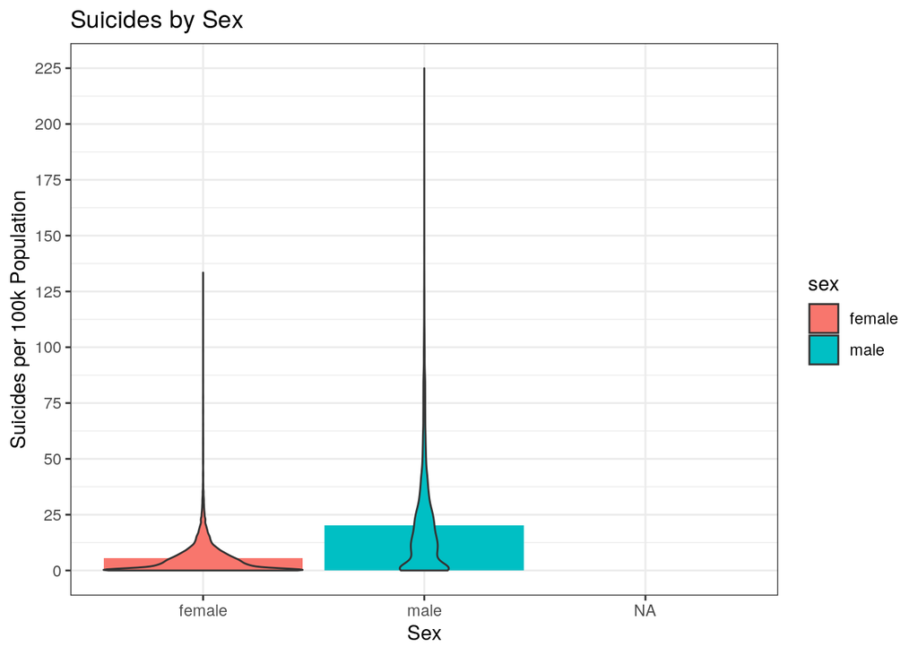

```r
# my plot 2: Suicidie by Sex
ggplot(mutateJoinedData, aes(sex, suicides_per_100k_pop, fill = sex)) +
    geom_bar(stat = "summary") + geom_violin() + theme_bw() +
    scale_y_continuous(n.breaks = 10) + xlab("Sex") + ylab("Suicides per 100k Population") +
    ggtitle("Suicides by Sex")
```

In this plot, we can see that suicide rates for males is much higher than for that of females. The violin structure of the male bar also rides up higher, indicating that there is also a higher variance among males. Considering a similar viewpoint from before (in terms of money), I could understand how this data could make sense: perhaps due to societal roles and men primarily being seen as “breadwinners” of the family, there may be more pressure on men to perform well financially.

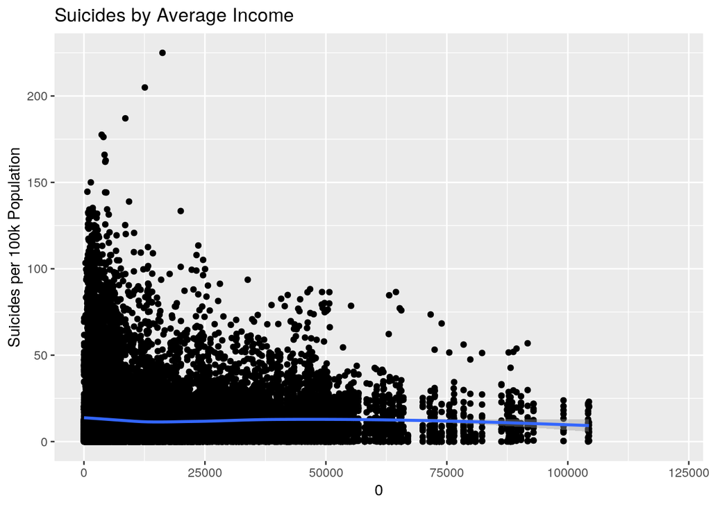

```r
# my plot 3: Suicides per Average Income
ggplot(mutateJoinedData, aes(Average_Income, suicides_per_100k_pop)) +
    geom_point() + geom_smooth(method = "loess") + scale_x_continuous((limits = c(0,
    150000))) + xlab("Average Income") + ylab("Suicides per 100k Population") +
    ggtitle("Suicides by Average Income")
```

In this plot, we see some contradicting data - it looks as though that countries with a lower average income have higher suicide rates. This rivals my first plot, which demonstrates that people in countries with a high income are more likely to commit suicide. This could be because these are average values.

#### Concluding Remarks

Considering the first plot created, I find it interesting that countries with a high income could have higher suicide rates. One thing I can consider to make sense out of this is the social technology that high income countries have: like social media. I wonder if this could be of negative influence to the population of high income countries.